# Place, Geography and Geospatial Data

## EHRI Geospatial Repository

Michal Frankl

Masaryk Institute and Archives, Czech Academy of Sciences

Created in Jupyter notebook.

## Maps in Holocaust Research and Remembrance

[figure not shown]

Vienna Wiesenthal Institute for Holocaust Studies

[figure not shown]

Vienna Wiesenthal Institute for Holocaust Studies

[figure not shown]

Eichmann Trial (Szczepan, Aleksandra. ‘Terra Incognita? Othering East-Central Europe in Holocaust Studies’)

[figure not shown]

Herbert Froboess, *Deutschland 1945* (Wiener Holocauset Library)

[figure not shown]

Gilbert, Martin. Atlas of the Holocaust. 3. vyd. Pergamon Press - Steimatzky, 1989.

[figure not shown]

US Holocaust Memorial Museum

[figure not shown]

Magocsi, Paul R., and Yohanan Petrovsky-Shtern. Jevreï ta Ukraïnci: tisjačolittja spivisnuvannja. Užhorod: Vydavnyctvo Valerija Padjaka, 2016.

[figure not shown]

"Nazi persecution" in Czech Historical Atlas (http://cha.fsv.cvut.cz/)

[figure not shown]

Holocaust Atlas of Lithuania

[figure not shown]

Tim Cole, Alberto Giordano, *The Budapest Ghetto dataset*

[figure not shown]

Tim Cole, Alberto Giordano, *Holocaust Survivors in Budapest dataset*

## Session overview

- EHRI and the Geospatial Repository
- Hands-on map making and data analysis
- Critical perspectives on geodata and feedback on platform

## EHRI and geospatial data

- Research infrastructure: provides data and services to researchers
- Launched 2010, will become a permanent, distributed European research infrastructure by early 2025
- Services:
  - EHRI Portal (https://portal.ehri-project.eu/)
  - EHRI editions
  - EHRI Document Blog (https://blog.ehri-project.eu/)
  - EHRI Research Guides (https://portal.ehri-project.eu/guides)
  - EHRI Dashboard (https://dashboard.ehri-project-stage.eu/)
  - EHRI Training site and MOOC
- Fellowships and workshops
- Works together with other RIs (especially CLARIN)

[figure not shown]

### EHRI Geospatial Repository

- response to user demands (focus groups, surveys) for data and training
- open data, FAIR principles
- using geospatial standards and services
- versatile, usage agnostic
- launched 2023, still in an early phase

[figure not shown]

## Search

- Fulltext search (example: [Prague](https://geodata.ehri-project.eu/geonetwork/srv/eng/catalog.search#/search?any=Prague&from=1&to=30)
- Facetted browse
- Map selecton

## Example dataset: ["Incidents" in Prague](https://geodata.ehri-project.eu/geonetwork/srv/eng/catalog.search#/metadata/71f1b57c-1704-482b-b041-d39cdc29bc30)

- description
- sources and limits
- structure
- license
- data via standard services

## Maps and diving into datasets

## Data analysis: Stolpersteine in Prague

[figure not shown]

- Does their spatial distribution correspond to places where Jews lived deportation?
- Is there a preference for spaces identified as "Jewish" or for affluent neighbourhoods?

### Load borders of historical districts

```python
districts = gpd.read_file("data/MGS-prague_districts_borders-v1.gpkg")
districts = districts.to_crs(("EPSG:4326"))
districts
```

|  | id | quarter_cs | quarter_en | geometry |
| --- | --- | --- | --- | --- |
| 0 | 5 | Praha IX | Prague IX | POLYGON ((14.54171 50.11815, 14.54262 50.12005... |
| 1 | 9 | Praha VIII | Prague VIII | POLYGON ((14.48048 50.11761, 14.48087 50.11763... |
| 2 | 11 | Praha XI | Prague XI | POLYGON ((14.53125 50.08599, 14.53158 50.08534... |
| 3 | 13 | Praha XIII | Prague XIII | POLYGON ((14.52331 50.07385, 14.52381 50.07396... |
| 4 | 15 | Praha XIX | Prague XIX | POLYGON ((14.33188 50.10859, 14.33202 50.10846... |
| 5 | 19 | Praha XVIII | Prague XVIII | POLYGON ((14.38049 50.07941, 14.38022 50.07944... |
| 6 | 14 | Praha XIV | Prague XIV | POLYGON ((14.46099 50.02918, 14.46127 50.02883... |
| 7 | 17 | Praha XVI | Prague XVI | POLYGON ((14.39799 50.02853, 14.39907 50.02832... |
| 8 | 18 | Praha XVII | Prague XVII | POLYGON ((14.37808 50.06377, 14.37867 50.06388... |
| 9 | 1 | Praha I | Prague I | POLYGON ((14.41035 50.07903, 14.41014 50.07919... |
| 10 | 3 | Praha III | Prague III | POLYGON ((14.40922 50.09266, 14.40942 50.09265... |
| 11 | 4 | Praha IV | Prague IV | POLYGON ((14.40922 50.09266, 14.40936 50.09288... |
| 12 | 6 | Praha V | Prague V | POLYGON ((14.41824 50.09165, 14.41844 50.09139... |
| 13 | 7 | Praha VI | Prague VI | POLYGON ((14.42112 50.06798, 14.42144 50.06749... |
| 14 | 8 | Praha VII | Prague VII | POLYGON ((14.42520 50.11531, 14.42666 50.11496... |
| 15 | 10 | Praha X | Prague X | POLYGON ((14.46374 50.09835, 14.46424 50.09753... |
| 16 | 12 | Praha XII | Prague XII | POLYGON ((14.43926 50.08598, 14.44041 50.08545... |
| 17 | 2 | Praha II | Prague II | POLYGON ((14.42677 50.09519, 14.42739 50.09525... |
| 18 | 16 | Praha XV | Prague XV | POLYGON ((14.44608 50.02608, 14.44642 50.02638... |

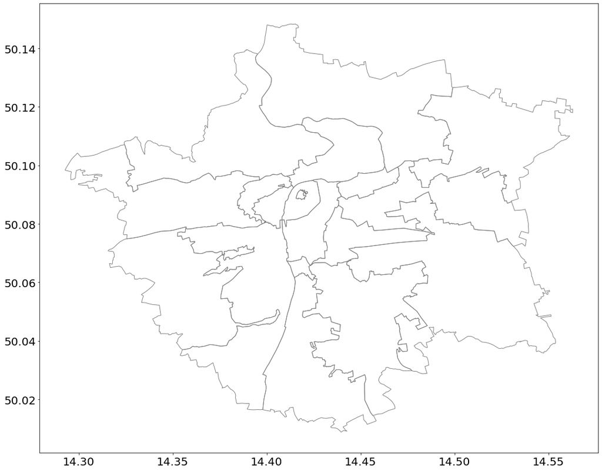

```python
districts.plot(facecolor="none", edgecolor='grey', figsize=(18, 18))
```

### Load dataset with places of residence of Jews in Prague

```python
houses = gpd.read_file("data/MGS-prague_jewish_residency_during_occupation-v1-eng.gpkg")
houses.head()
```

|  | address_en | address_de | count | murdered | survived | fate_unknown | present_1942-01-01 | present_1943-01-01 | present_1944-01-01 | present_1945-01-01 | present_1945-05-09 | geometry |
| --- | --- | --- | --- | --- | --- | --- | --- | --- | --- | --- | --- | --- |
| 0 | Prague XIV, Budějovická 93 | Prag XIV, Budweiser Strasse 93 | 4.0 | 3.0 | 0.0 | 1.0 | 3.0 | 0.0 | 0.0 | 0.0 | 0.0 | POINT (14.45749 50.03868) |
| 1 | Prague XIV, Nová cesta 9/510 | Prag XIV, Neuer Weg 9/510 | 3.0 | 3.0 | 0.0 | 0.0 | 3.0 | 0.0 | 0.0 | 0.0 | 0.0 | POINT (14.43475 50.03913) |
| 2 | Prague XV, Branická 19/722 | Prag XV, Braniker Strasse 19/722 | 13.0 | 10.0 | 0.0 | 3.0 | 7.0 | 1.0 | 1.0 | 0.0 | 0.0 | POINT (14.41132 50.03950) |
| 3 | Prague XIV, K Habrovce 85 | Prag XIV, Zu den Hainbuchen 85 | 6.0 | 6.0 | 0.0 | 0.0 | 5.0 | 2.0 | 0.0 | 0.0 | 0.0 | POINT (14.45105 50.04095) |
| 4 | Prague XIII, Jihozápadní IV 2321 | Prag XIII, Südweststrasse 2321 | 5.0 | 5.0 | 0.0 | 0.0 | 4.0 | 0.0 | 0.0 | 0.0 | 0.0 | POINT (14.47943 50.04131) |

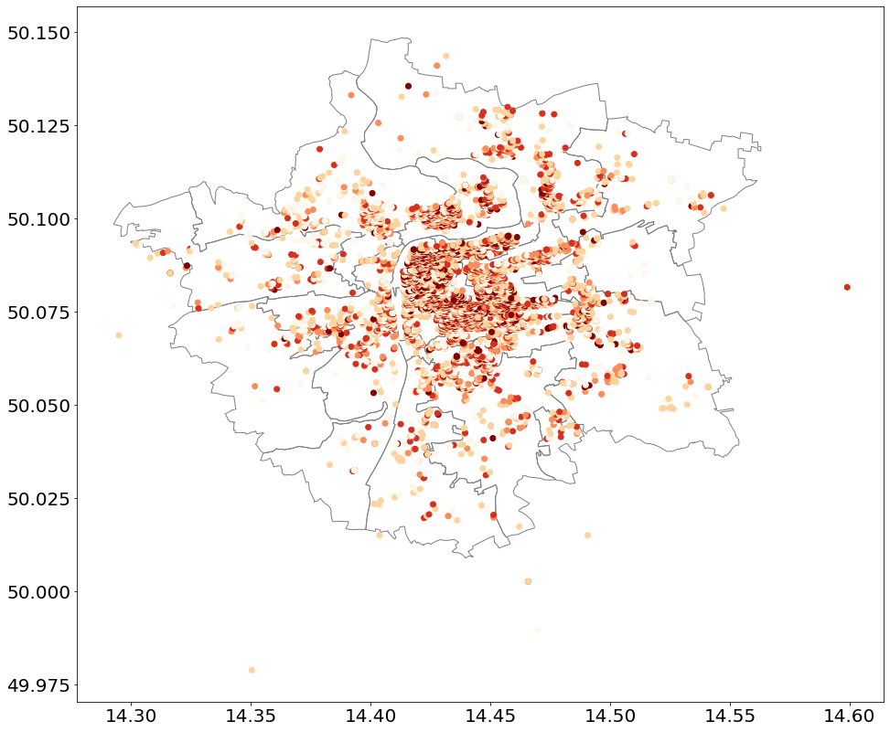

```python
fig, ax = plt.subplots(figsize=(20,14))
districts.plot(facecolor="none", edgecolor='grey', ax=ax)
houses.plot(cmap="OrRd", column="murdered", scheme="Quantiles", ax=ax)
```

### Load Stolpersteine dataset

```python
stolpersteine = gpd.read_file("data/STS-stolpersteine_prague-v2_20230930.gpkg")
stolpersteine = stolpersteine.to_crs("EPSG:4326")
stolpersteine.head()
```

|  | id | person | address_cs | address_en | link_stolpersteine_cs | link_stolpersteine_en | link_holocaustcz_cs | link_holocaustcz_en | geometry |
| --- | --- | --- | --- | --- | --- | --- | --- | --- | --- |
| 0 | 1 | Pollaková Eva Mia (* 1924) | Praha 1, 17. listopadu 207/6 | Prague 1, 17. listopadu 207/6 | http://stolpersteinecz.cz/mia-pollakova | http://stolpersteinecz.cz/en/mia-pollakova | https://www.holocaust.cz/databaze-obeti/obet/1... | https://www.holocaust.cz/en/database-of-victim... | POINT (14.41754 50.09120) |
| 1 | 2 | Pollaková Vilma (* 1897) | Praha 1, 17. listopadu 207/6 | Prague 1, 17. listopadu 207/6 | http://stolpersteinecz.cz/vilma-pollakova | http://stolpersteinecz.cz/en/vilma-pollakova/ | https://www.holocaust.cz/databaze-obeti/obet/1... | https://www.holocaust.cz/en/database-of-victim... | POINT (14.41754 50.09120) |
| 2 | 3 | Fahnová Helena (* 1919) | Praha 1, 17. listopadu 4-6 | Prague 1, 17. listopadu 4-6 | http://stolpersteinecz.cz/fahnova-helena | http://stolpersteinecz.cz/en/fahnova-helena | https://www.holocaust.cz/databaze-obeti/obet/8... | https://www.holocaust.cz/en/database-of-victim... | POINT (14.41769 50.09129) |
| 3 | 4 | Fahn Karel (* 1914) | Praha 1, 17. listopadu 4-6 | Prague 1, 17. listopadu 4-6 | http://stolpersteinecz.cz/fahn-karel | http://stolpersteinecz.cz/en/fahn-karel | https://www.holocaust.cz/databaze-obeti/obet/8... | https://www.holocaust.cz/en/database-of-victim... | POINT (14.41769 50.09129) |
| 4 | 5 | Markusová Berta (* 1887) | Praha 1, 17. listopadu 4-6 | Prague 1, 17. listopadu 4-6 | http://stolpersteinecz.cz/markusova-berta-roz-... | http://stolpersteinecz.cz/en/markusova-berta-r... | https://www.holocaust.cz/databaze-obeti/obet/1... | https://www.holocaust.cz/en/database-of-victim... | POINT (14.41769 50.09129) |

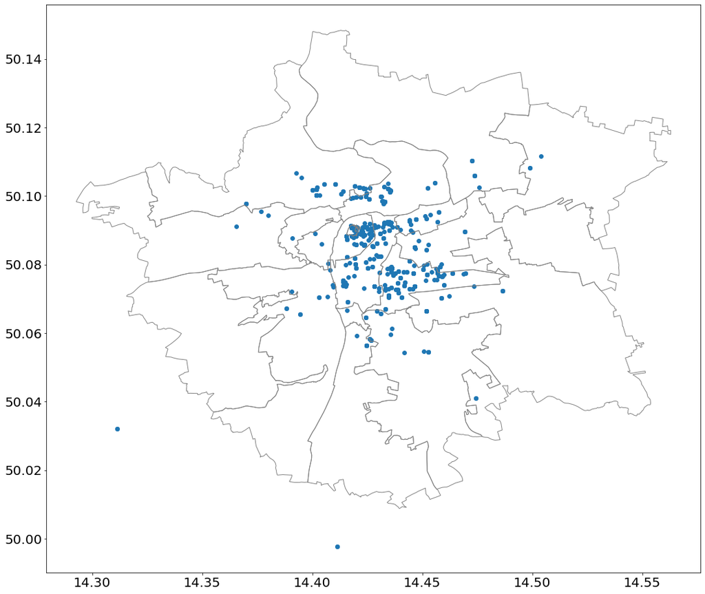

```python
fig, ax = plt.subplots(figsize=(18, 18))
stolpersteine.plot(ax=ax)
districts.plot(facecolor="none", edgecolor='grey', ax=ax)
```

```python
hs = dhgrouped.join(dsgrouped, on="quarter_en")
hs.rename({'quarter_en': 'stolpersteine'}, axis=1, inplace=True)
hs['proportion'] = hs['stolpersteine'] / hs['murdered']
hs.sort_values(['proportion'], ascending=[False])
```

| quarter_en | murdered | stolpersteine | proportion |
| --- | --- | --- | --- |
| Prague XIX | 544.0 | 54 | 0.099265 |
| Prague VII | 1493.0 | 50 | 0.033490 |
| Prague III | 111.0 | 3 | 0.027027 |
| Prague XV | 238.0 | 6 | 0.025210 |
| Prague XIV | 884.0 | 21 | 0.023756 |
| Prague VI | 44.0 | 1 | 0.022727 |
| Prague IX | 134.0 | 3 | 0.022388 |
| Prague II | 5659.0 | 123 | 0.021735 |
| Prague V | 1692.0 | 33 | 0.019504 |
| Prague XII | 7001.0 | 134 | 0.019140 |
| Prague XVI | 654.0 | 11 | 0.016820 |
| Prague XVIII | 192.0 | 3 | 0.015625 |
| Prague IV | 70.0 | 1 | 0.014286 |
| Prague I | 5543.0 | 77 | 0.013891 |
| Prague X | 1975.0 | 23 | 0.011646 |
| Prague VIII | 807.0 | 8 | 0.009913 |
| Prague XI | 2248.0 | 19 | 0.008452 |
| Prague XIII | 2022.0 | 17 | 0.008408 |
| Prague XVII | 122.0 | 1 | 0.008197 |

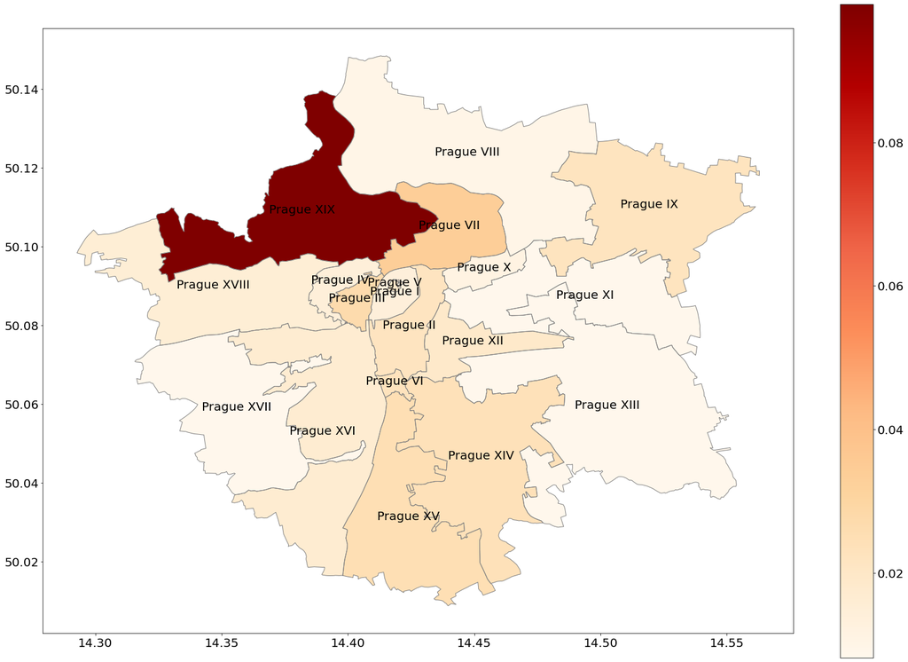

```python
diststat = districts.merge(hs, on='quarter_en', how='left')
fig, ax = plt.subplots(figsize = (28, 20))
diststat[(diststat["murdered"]>0)].plot(cmap="OrRd", column="proportion", legend=1, ax=ax)
diststat.apply(lambda x: ax.annotate(text=x['quarter_en'], xy=x.geometry.centroid.coords[0], ha='center'),axis=1); #  + ': ' + str(x['stolpersteine']) + '/' + str(x['murdered'])
districts.plot(facecolor="none", edgecolor='grey', ax=ax)
```

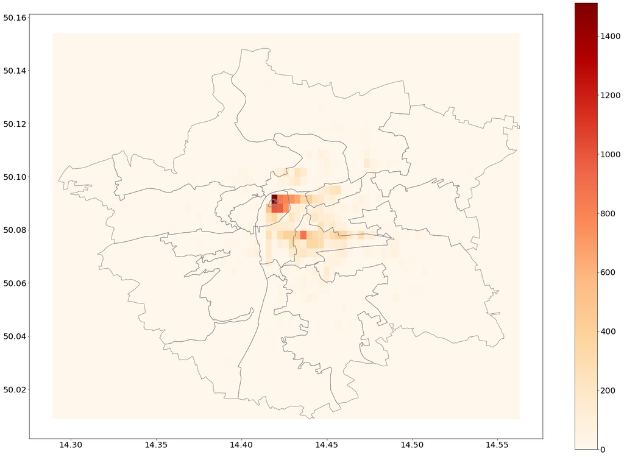

```python
gridh3 = cell.join(gridh2, on="gridid", how="inner", rsuffix="_right")
fig, ax = plt.subplots(figsize = (28, 20))
gridh3.plot(figsize = (28, 20), cmap="OrRd", column="murdered", legend=1, ax=ax)
districts.plot(facecolor="none", edgecolor='grey', ax=ax)
```

[figure not shown]

```python
grids3 = cell.join(grids2, on="gridid", how="inner", rsuffix="_right")
fig, ax = plt.subplots(figsize = (28, 20))
grids3.plot(figsize = (28, 20), column="geometry_right", cmap="OrRd", legend=1, ax=ax)
districts.plot(facecolor="none", edgecolor='grey', ax=ax)
```

## Discussion

- What critical approaches to data and GIS mean for a repository
  - How to combine need for data and destabilise outdated perspectives on place and space, maps and mapping?
- Feedback on repository
  - What didn't work?
  - What support needed?
  - Would you contribute?
  - Anything else?